# Week 1 Homework

### Question 6A

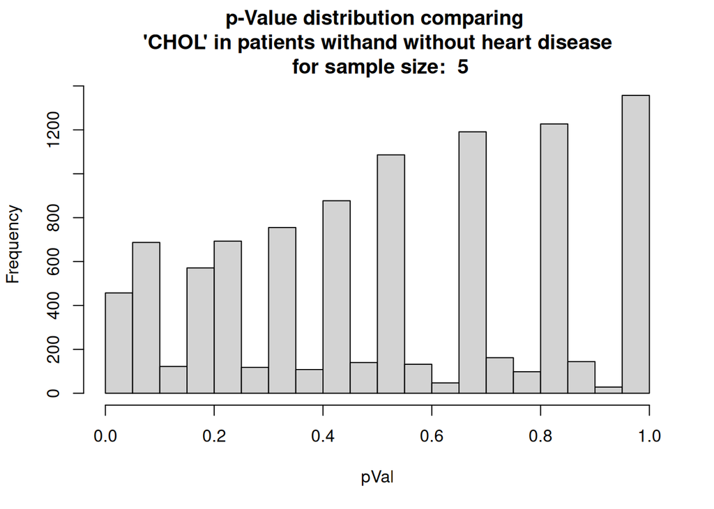

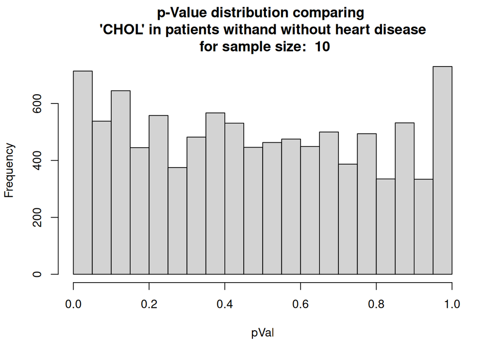

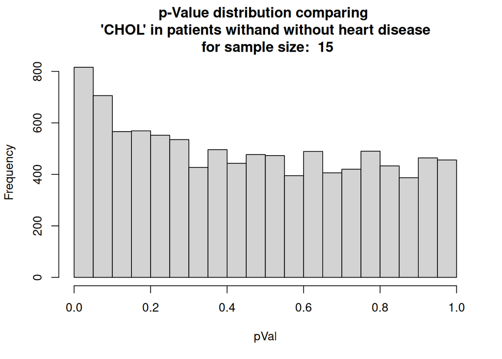

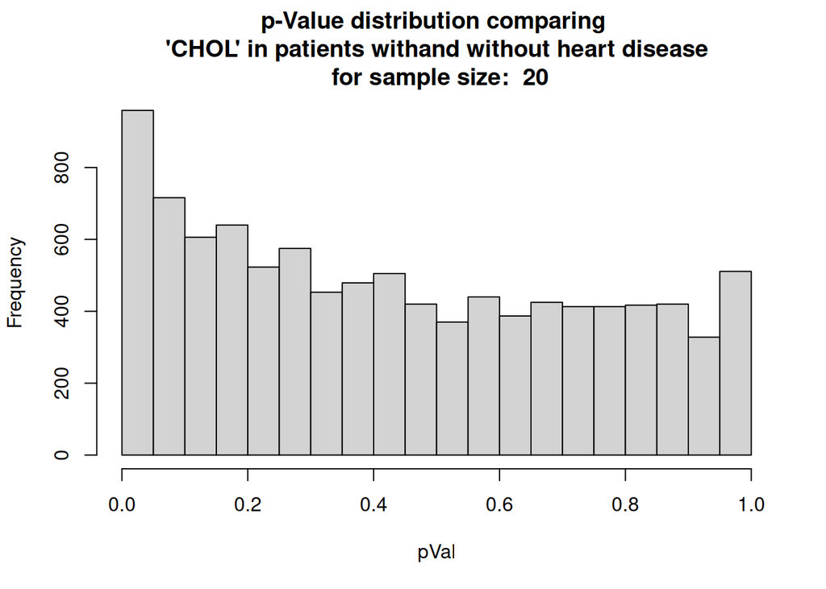

```r
sim <- 10000
sampleSizes <- seq(5,20,5)


CHOL.power <- numeric(length(sampleSize))

for (i in 1:length(sampleSizes)){
  count <- 0
  sampleSize <- sampleSizes[i]
  pVal <- numeric(sim)
  for (j in 1:sim){
    yes.data <- sample(y.HD$CHOL, sampleSize)
    no.data <- sample(n.HD$CHOL, sampleSize)
    pVal[j] <- wilcox.test(yes.data, no.data)$p.value
    if (pVal[j] <= 0.05){
      count <- count + 1
    }
  }
  hist(pVal, main=paste("p-Value distribution comparing \n 'CHOL' in patients withand without heart disease \n for sample size: ", sampleSize))
  CHOL.power[i] <- count/sim
}
```

### Question 6B

Comparing the means and variance from data table, it would appear that the “CP” column may have the least overlap, due to difference in mean being further apart compared to the variance.

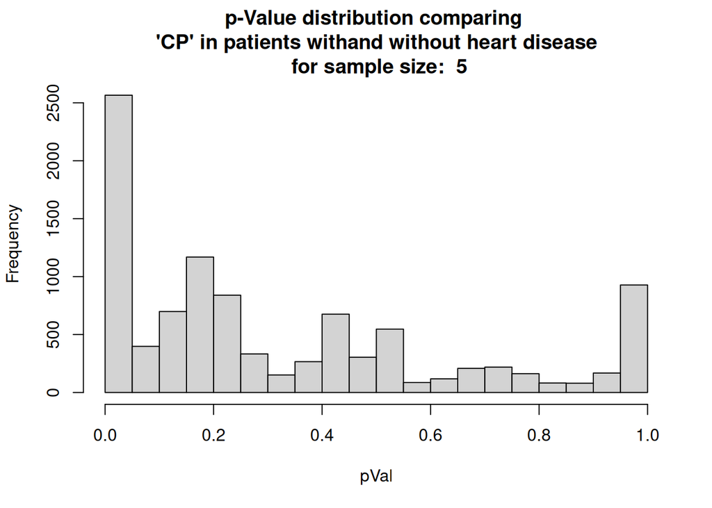

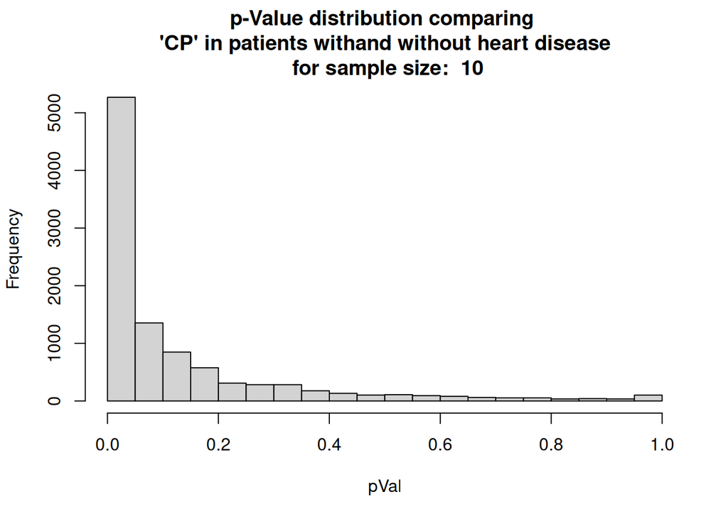

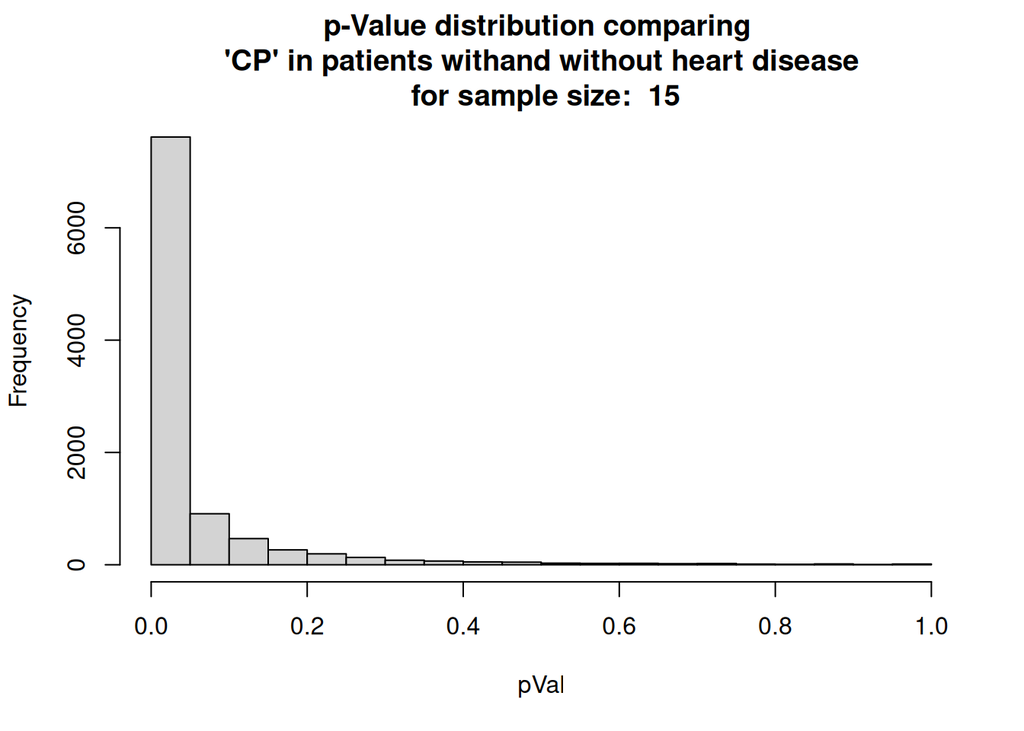

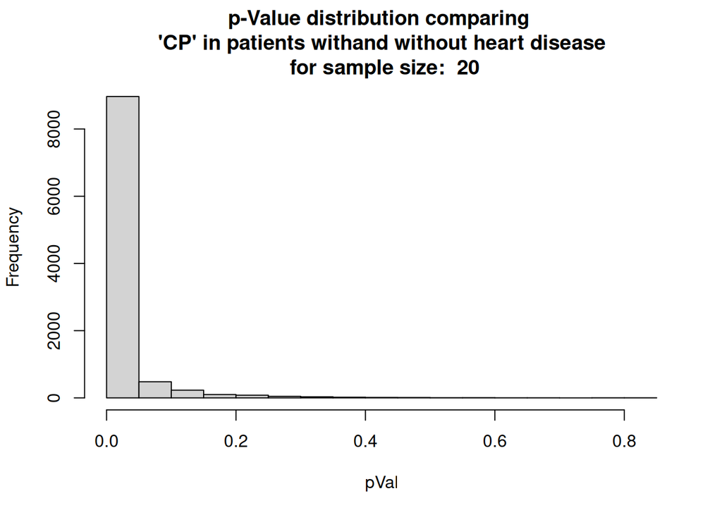

```r
sim <- 10000
sampleSizes <- seq(5,20,5)


CP.power <- numeric(length(sampleSize))

for (i in 1:length(sampleSizes)){
  count <- 0
  sampleSize <- sampleSizes[i]
  pVal <- numeric(sim)
  for (j in 1:sim){
    yes.data <- sample(y.HD$CP, sampleSize)
    no.data <- sample(n.HD$CP, sampleSize)
    pVal[j] <- wilcox.test(yes.data, no.data)$p.value
    if (pVal[j] <= 0.05){
      count <- count + 1
    }
  }
  hist(pVal, main=paste("p-Value distribution comparing \n 'CP' in patients withand without heart disease \n for sample size: ", sampleSize))
  CP.power[i] <- count/sim
}
```

### Question 6C

Let’s now evaluate the power behind these statistcal tests for both “CHOL” and “CP” columns.

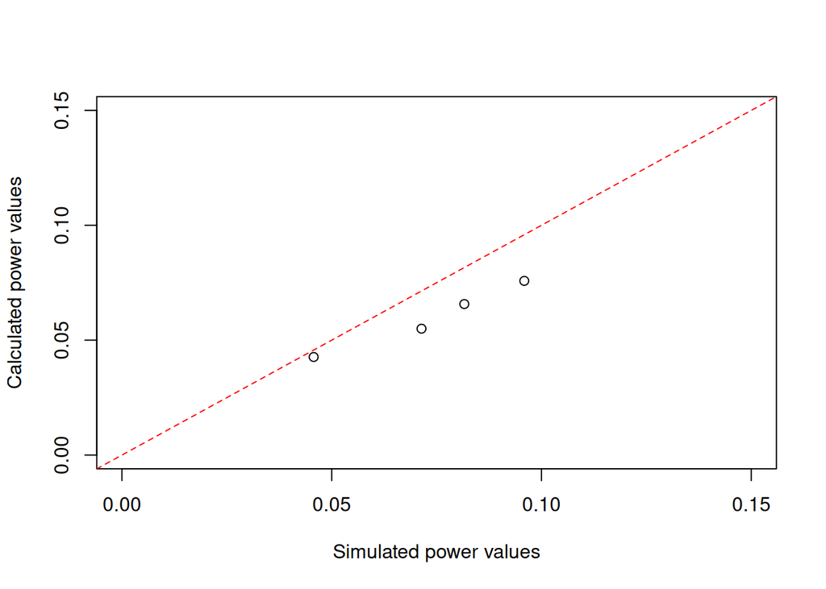

```r
CP.mean.diff <- DT$Yes.HD.mean[1] - DT$No.HD.mean[1]
CP.power.Val <- numeric(length(sampleSizes))
for (i in 1:length(sampleSizes)){
  sampleSize <- sampleSizes[i]
  CP.power.Val[i] <- power.t.test(n=sampleSize,
                            delta = CP.mean.diff,
                            sd = sd(data$CP),
                            sig.level = 0.05)$power

}


CHOL.mean.diff <- DT$Yes.HD.mean[3] - DT$No.HD.mean[3]
CHOL.power.Val <- numeric(length(sampleSizes))
for (i in 1:length(sampleSizes)){
  sampleSize <- sampleSizes[i]
  CHOL.power.Val[i] <- power.t.test(n=sampleSize,
                            delta = CHOL.mean.diff,
                            sd = sd(data$CHOL),
                            sig.level = 0.05)$power

}

highestPower <- CHOL.power.Val[4]

plot(CHOL.power, CHOL.power.Val, xlim=c(0,.15), ylim=c(0,.15), xlab="Simulated power values", ylab="Calculated power values")
abline(0, 1, col = "red", lty = 2)
```

```r
#plot(CP.power, CP.power.Val, xlim=c(0,1), ylim=c(0,1), xlab="Simulated power values", ylab="Calculated power values")
#abline(0, 1, col = "red", lty = 2)

# Finding the size needed for a power of 0.8 for the "CP" column
sizeNeeded <- power.t.test(delta = CP.mean.diff, power = 0.8, sd = sd(data$CP), sig.level = 0.05)$n
```

The analytically calculated power value, for the CHOL column, increases as sample size increases. This makes sense as we observe a larger number of < 0.05 p value distribution as sample size increases. However the power is still quite low even with a sample size of 20 0.075802.

The sample size needed to obtain a power of at-least 0.8 for the “CP” column is 23.7668896. This makes sense as when we look at the distributions of p-values there is not much of a change between 15 and 20 sample sizes. And we are observing over 8000 p-values below 0.05.

## Citations

1. Andras Janosi, W. S. (1989). Heart Disease [Data set]. UCI Machine Learning Repository. https://doi.org/10.24432/C52P4X
2. OpenAI. (2026). ChatGPT (GPT-6) [Large language model]. OpenAI ChatGPT